# Fisher KPP with Julia

This implementation of numerical solve of a reaction diffusion equation is based on the [presentation](https://www.youtube.com/watch?v=8gLhaWRYvfQ) of the package `MethodOfLines.jl` at JuliaCon 2022 by A. Jones.

## Fisher KPP equation

The Fisher KPP equation (Fisher’s version) reads:

$$\frac{\partial u}{\partial t} = ru\left(1-u\right) + D \frac{\partial^2 u}{\partial x^2},$$

with $u(t,x)$ the population density at time $t$ and position $x$ (scaled to the local carrying capacity $K$), $r$ the intrinsic growth rate of the population, and $D$ the diffusion coefficient.

## Packages

Let us first import the packages used for the simulation:

```julia
using MethodOfLines,
      ModelingToolkit,
      DomainSets,
      OrdinaryDiffEq,
      Plots,
      LaTeXStrings
```

## Model definition

`MethodsOfLines.jl` makes use of `ModelingToolkit.jl` to symbolically define the model to integrate.

Let us first define the time and space parameters:

```julia
@parameters t, x
```

Now the variable $u(t,x)$:

```julia
@variables u(..)
```

And finally the derivatives:

```julia
Dt = Differential(t)
Dx = Differential(x)
Dxx = Differential(x)^2
```

We also define the parameters $r$ and $D$ as global variables (not the best design, can be improved).

```julia
r = 1.0
D = 1.0
```

We can now define the model symbolically through:

```julia
eq = Dt(u(t, x)) ~ r * u(t,x) * (1-u(t,x)) + D * Dxx(u(t,x))
```

$$\begin{equation}
\frac{\mathrm{d}}{\mathrm{d}t} u\left( t, x \right) = \left( 1 - u\left( t, x \right) \right) u\left( t, x \right) + \frac{\mathrm{d}}{\mathrm{d}x} \frac{\mathrm{d}}{\mathrm{d}x} u\left( t, x \right)
\end{equation}$$

## Domains of integration

Let us introduce some parameters for space and time domains:

```julia
x_max = 30.0
t_max = 14.0
```

And the domains of integration:

```julia
domain = [x ∈ Interval(0.0, x_max),
          t ∈ Interval(0.0, t_max)]
```

We also introduce (initial and) boundary conditions:

```julia
ic_bc = [u(0.0, x) ~ 0.0,
         u(t, 0.0) ~ 1.0,
         u(t, x_max) ~ 0.0]
```

## Simulation

We define the model to be integrated as a `PDESystem`, from the equation `eq`, the initial and boundary conditions `ic_bc`, the domains of integration `domain`, the time and space parameters `t` and `x`, and the solution we want to retrieve `u(t,x)`:

```julia
@named sys = PDESystem(eq, ic_bc, domain, [t, x], [u(t,x)])
```

We set up the discretization of space, through `MethodOfLines.jl`:

```julia
dx = 0.1
discretization = MOLFiniteDifference([x => dx], t)
```

And we set up the (ODE) problem to be integrated:

```julia
prob = discretize(sys, discretization)
```

And we finally integrate it through the `OrdinaryDiffEq.jl` solver with `Tsit5` algorithm.

```julia
sol = solve(prob, Tsit5(), saveat = .1)
```

## Graphical representation

We retrieve the components of the solution for easier manipulation:

```julia
gridx = sol[x]
gridt = sol[t]
solu = sol[u(t,x)]
```

And we plot the animation of the solution through time:

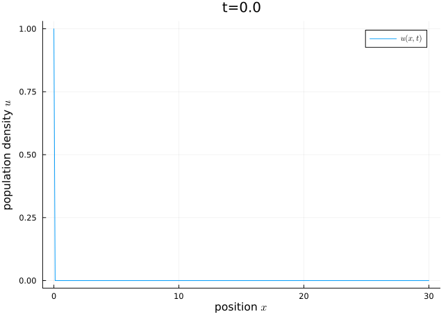

```julia
anim = @animate for i in eachindex(gridt)
    plot(gridx, solu[i, :],
         xlabel = "position "*L"$x$",
         ylabel = "population density "*L"$u$",
         label = L"$u(x,t)$",
         title = "t=$(gridt[i])")
end

gif(anim, "fisherKPP.gif", fps = 10)
```

And that’s it !